# 4-Classifiers

# k-NN

This notebook illustrates the code for Classifiers module. We will continue to use the Caret Package. The caret package (short for Classification And REgression Training) is a set of functions that attempt to streamline the process for creating predictive models. The package contains tools for:

- data splitting/partitioning
- pre-processing
- feature selection
- model tuning using resampling

Some code in this package comes from the following reference:

- https://www.dataminingbook.com/book/r-edition

Install packages if necessary. Uncomment before running.

```r
#install.packages("caret")
library(caret)

# install.packages("ISLR") # only install if needed
library(ISLR)
```

## Data Splitting

We will use the UniversalBank datasets.

```r
head(UniversalBank)
```

| ID | Age | Experience | Income | ZIP Code | Family | CCAvg | Education | Mortgage | Personal Loan | Securities Account | CD Account | Online | CreditCard |
| --- | --- | --- | --- | --- | --- | --- | --- | --- | --- | --- | --- | --- | --- |
| 1 | 25 | 1 | 49 | 91107 | 4 | 1.6 | 1 | 0 | 0 | 1 | 0 | 0 | 0 |
| 2 | 45 | 19 | 34 | 90089 | 3 | 1.5 | 1 | 0 | 0 | 1 | 0 | 0 | 0 |
| 3 | 39 | 15 | 11 | 94720 | 1 | 1.0 | 1 | 0 | 0 | 0 | 0 | 0 | 0 |
| 4 | 35 | 9 | 100 | 94112 | 1 | 2.7 | 2 | 0 | 0 | 0 | 0 | 0 | 0 |
| 5 | 35 | 8 | 45 | 91330 | 4 | 1.0 | 2 | 0 | 0 | 0 | 0 | 0 | 1 |
| 6 | 37 | 13 | 29 | 92121 | 4 | 0.4 | 2 | 155 | 0 | 0 | 0 | 1 | 0 |

```r
summary(UniversalBank)
```

```
       ID            Age          Experience       Income          ZIP Code         Family          CCAvg        Education    Mortgage     Personal Loan
 Min.   :   1   Min.   :23.00   Min.   :-3.0   Min.   :  8.00   Min.   : 9307   Min.   :1.000   Min.   : 0.000   1:2096    Min.   :  0.0   Min.   :0.000
 1st Qu.:1251   1st Qu.:35.00   1st Qu.:10.0   1st Qu.: 39.00   1st Qu.:91911   1st Qu.:1.000   1st Qu.: 0.700   2:1403    1st Qu.:  0.0   1st Qu.:0.000
 Median :2500   Median :45.00   Median :20.0   Median : 64.00   Median :93437   Median :2.000   Median : 1.500   3:1501    Median :  0.0   Median :0.000
 Mean   :2500   Mean   :45.34   Mean   :20.1   Mean   : 73.77   Mean   :93153   Mean   :2.396   Mean   : 1.938             Mean   : 56.5   Mean   :0.096
 3rd Qu.:3750   3rd Qu.:55.00   3rd Qu.:30.0   3rd Qu.: 98.00   3rd Qu.:94608   3rd Qu.:3.000   3rd Qu.: 2.500             3rd Qu.:101.0   3rd Qu.:0.000
 Max.   :5000   Max.   :67.00   Max.   :43.0   Max.   :224.00   Max.   :96651   Max.   :4.000   Max.   :10.000             Max.   :635.0   Max.   :1.000
 Securities Account   CD Account         Online         CreditCard
 Min.   :0.0000     Min.   :0.0000   Min.   :0.0000   Min.   :0.000
 1st Qu.:0.0000     1st Qu.:0.0000   1st Qu.:0.0000   1st Qu.:0.000
 Median :0.0000     Median :0.0000   Median :1.0000   Median :0.000
 Mean   :0.1044     Mean   :0.0604   Mean   :0.5968   Mean   :0.294
 3rd Qu.:0.0000     3rd Qu.:0.0000   3rd Qu.:1.0000   3rd Qu.:1.000
 Max.   :1.0000     Max.   :1.0000   Max.   :1.0000   Max.   :1.000
```

Assume that we are interested in creating a training and validation set from this dataset.

- First, we create a dataset with only the required columns. We will use the dplyr package. Install it if necessary
- Then, we create an index for the training sample.
- We next create the training dataset
- We then use the reverse index of the training sample to create the validation set

```r
library(dplyr)
gsub(" ",".",colnames("Personal Loan"),("Securities Account"),("CD Account"))
```

```
character(0)
```

```r
m_universalbank <- select(UniversalBank,Age,Experience,Income,Family,CCAvg,Education,Mortgage,Online,CreditCard) # Select a subset of variables

set.seed(15)
Test_Index = createDataPartition(m_universalbank$Age,p=0.6, list=FALSE) # 60% reserved for Test
Test_Data = m_universalbank[Test_Index,]
TraVal_Data = m_universalbank[-Test_Index,] # Validation and Training data is rest

Train_Index = createDataPartition(TraVal_Data$Age,p=0.4, list=FALSE) # 40% of remaining data as training
Train_Data = TraVal_Data[Train_Index,]
Validation_Data = TraVal_Data[-Train_Index,] # rest as validation

summary(Train_Data)
```

```
      Age          Experience        Income           Family          CCAvg       Education    Mortgage          Online         CreditCard
 Min.   :24.00   Min.   :-3.00   Min.   :  8.00   Min.   :1.000   Min.   :0.000   1:340     Min.   :  0.00   Min.   :0.0000   Min.   :0.000
 1st Qu.:35.00   1st Qu.:10.00   1st Qu.: 39.00   1st Qu.:1.000   1st Qu.:0.700   2:232     1st Qu.:  0.00   1st Qu.:0.0000   1st Qu.:0.000
 Median :45.00   Median :20.00   Median : 64.00   Median :2.000   Median :1.600   3:230     Median :  0.00   Median :1.0000   Median :0.000
 Mean   :45.32   Mean   :20.06   Mean   : 74.09   Mean   :2.446   Mean   :1.992             Mean   : 52.05   Mean   :0.6234   Mean   :0.298
 3rd Qu.:55.00   3rd Qu.:30.00   3rd Qu.: 98.00   3rd Qu.:4.000   3rd Qu.:2.600             3rd Qu.: 93.50   3rd Qu.:1.0000   3rd Qu.:1.000
 Max.   :67.00   Max.   :42.00   Max.   :200.00   Max.   :4.000   Max.   :9.000             Max.   :582.00   Max.   :1.0000   Max.   :1.000
```

```r
summary(Validation_Data)
```

```
      Age          Experience        Income           Family          CCAvg        Education    Mortgage          Online         CreditCard
 Min.   :23.00   Min.   :-3.00   Min.   :  8.00   Min.   :1.000   Min.   : 0.000   1:512     Min.   :  0.00   Min.   :0.0000   Min.   :0.0000
 1st Qu.:35.00   1st Qu.:10.00   1st Qu.: 38.00   1st Qu.:1.000   1st Qu.: 0.600   2:321     1st Qu.:  0.00   1st Qu.:0.0000   1st Qu.:0.0000
 Median :45.00   Median :20.00   Median : 61.00   Median :2.000   Median : 1.500   3:364     Median :  0.00   Median :1.0000   Median :0.0000
 Mean   :45.23   Mean   :20.02   Mean   : 71.77   Mean   :2.372   Mean   : 1.909             Mean   : 52.94   Mean   :0.6099   Mean   :0.2932
 3rd Qu.:55.00   3rd Qu.:30.00   3rd Qu.: 94.00   3rd Qu.:3.000   3rd Qu.: 2.500             3rd Qu.: 98.00   3rd Qu.:1.0000   3rd Qu.:1.0000
 Max.   :67.00   Max.   :43.00   Max.   :218.00   Max.   :4.000   Max.   :10.000             Max.   :589.00   Max.   :1.0000   Max.   :1.0000
```

```r
summary(Test_Data)
```

```
      Age          Experience        Income           Family          CCAvg        Education    Mortgage          Online         CreditCard
 Min.   :23.00   Min.   :-3.00   Min.   :  8.00   Min.   :1.000   Min.   : 0.000   1:1244    Min.   :  0.00   Min.   :0.0000   Min.   :0.0000
 1st Qu.:35.00   1st Qu.:10.00   1st Qu.: 39.00   1st Qu.:1.000   1st Qu.: 0.700   2: 850    1st Qu.:  0.00   1st Qu.:0.0000   1st Qu.:0.0000
 Median :45.00   Median :20.00   Median : 64.00   Median :2.000   Median : 1.600   3: 907    Median :  0.00   Median :1.0000   Median :0.0000
 Mean   :45.39   Mean   :20.15   Mean   : 74.49   Mean   :2.393   Mean   : 1.935             Mean   : 59.11   Mean   :0.5845   Mean   :0.2932
 3rd Qu.:55.00   3rd Qu.:30.00   3rd Qu.: 99.00   3rd Qu.:3.000   3rd Qu.: 2.500             3rd Qu.:103.00   3rd Qu.:1.0000   3rd Qu.:1.0000
 Max.   :67.00   Max.   :43.00   Max.   :224.00   Max.   :4.000   Max.   :10.000             Max.   :635.00   Max.   :1.0000   Max.   :1.0000
```

## Plotting

Let us plot the data. I recommend you use ggplot, instead of the plot command.

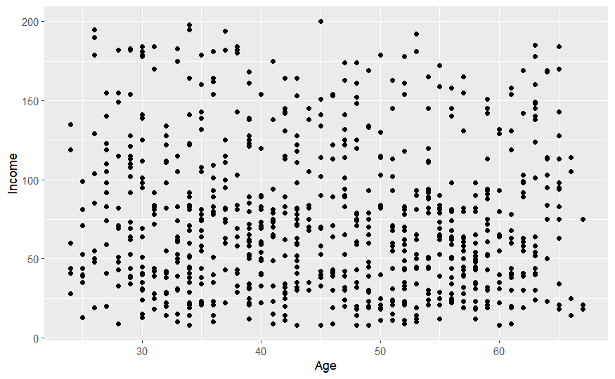

```r
library(ggplot2)
ggplot(Train_Data, aes(x=Age,y=Income,)) +
geom_point()
```

## Normalization

Let us now normalize the data.

The preProcess ( ) function that is in the ‘caret’ package is a powerful method that has implemented a number of data processing and transformation methods.

The function implements min-max normalization using “range” as the method or z-score scaling when using “center” and “scale” as input method parameters.

```r
library(class)
# Copy the original data
train.norm.df <- Train_Data
valid.norm.df <- Validation_Data
traval.norm.df <- TraVal_Data

# use preProcess()
norm.values <- preProcess(Train_Data[, 2:3], method=c("center", "scale"))

train.norm.df[, 2:3] <- predict(norm.values, Train_Data[, 2:3]) # Replace first two columns with normalized values
valid.norm.df[, 2:3] <- predict(norm.values, Validation_Data[, 2:3])
traval.norm.df[, 2:3] <- predict(norm.values, traval.norm.df[, 2:3])
test.norm.df <- predict(norm.values, Test_Data)

summary(train.norm.df)
```

```
      Age          Experience            Income            Family          CCAvg       Education    Mortgage          Online         CreditCard
 Min.   :24.00   Min.   :-2.034704   Min.   :-1.4396   Min.   :1.000   Min.   :0.000   1:340     Min.   :  0.00   Min.   :0.0000   Min.   :0.000
 1st Qu.:35.00   1st Qu.:-0.887701   1st Qu.:-0.7643   1st Qu.:1.000   1st Qu.:0.700   2:232     1st Qu.:  0.00   1st Qu.:0.0000   1st Qu.:0.000
 Median :45.00   Median :-0.005391   Median :-0.2198   Median :2.000   Median :1.600   3:230     Median :  0.00   Median :1.0000   Median :0.000
 Mean   :45.32   Mean   : 0.000000   Mean   : 0.0000   Mean   :2.446   Mean   :1.992             Mean   : 52.05   Mean   :0.6234   Mean   :0.298
 3rd Qu.:55.00   3rd Qu.: 0.876919   3rd Qu.: 0.5209   3rd Qu.:4.000   3rd Qu.:2.600             3rd Qu.: 93.50   3rd Qu.:1.0000   3rd Qu.:1.000
 Max.   :67.00   Max.   : 1.935691   Max.   : 2.7427   Max.   :4.000   Max.   :9.000             Max.   :582.00   Max.   :1.0000   Max.   :1.000
```

```r
var(train.norm.df[, 2:3])
```

```
           Experience     Income
Experience  1.0000000 -0.0612647
Income     -0.0612647  1.0000000
```

```r
summary(valid.norm.df)
```

```
      Age          Experience            Income             Family          CCAvg        Education    Mortgage          Online         CreditCard
 Min.   :23.00   Min.   :-2.034704   Min.   :-1.43959   Min.   :1.000   Min.   : 0.000   1:512     Min.   :  0.00   Min.   :0.0000   Min.   :0.0000
 1st Qu.:35.00   1st Qu.:-0.887701   1st Qu.:-0.78611   1st Qu.:1.000   1st Qu.: 0.600   2:321     1st Qu.:  0.00   1st Qu.:0.0000   1st Qu.:0.0000
 Median :45.00   Median :-0.005391   Median :-0.28510   Median :2.000   Median : 1.500   3:364     Median :  0.00   Median :1.0000   Median :0.0000
 Mean   :45.23   Mean   :-0.003474   Mean   :-0.05046   Mean   :2.372   Mean   : 1.909             Mean   : 52.94   Mean   :0.6099   Mean   :0.2932
 3rd Qu.:55.00   3rd Qu.: 0.876919   3rd Qu.: 0.43373   3rd Qu.:3.000   3rd Qu.: 2.500             3rd Qu.: 98.00   3rd Qu.:1.0000   3rd Qu.:1.0000
 Max.   :67.00   Max.   : 2.023922   Max.   : 3.13480   Max.   :4.000   Max.   :10.000             Max.   :589.00   Max.   :1.0000   Max.   :1.0000
```

```r
var(valid.norm.df[, 2:3])
```

```
            Experience      Income
Experience  1.01655188 -0.07633053
Income     -0.07633053  1.02849605
```